[O’Hara on GitHub](https://github.com/oharac)

# Examine missingness of grouping traits for MICE

Compiled on Thu Jan 27 10:06:20 2022 by ohara

```r
knitr::opts_chunk$set(echo = TRUE, message = FALSE, warning = FALSE)

library(oharac)
oharac::setup()
source(here('common_fxns.R'))
library(mice)
```

# 1 Summary

Read in processed traits data as a dataframe. Identify missingness, overall and by taxonomic grouping, to identify challenges in using MICE for imputation of missing values.

# 2 Data

See individual trait scripts.

# 3 Methods

## 3.1 Read in and process traits

These initially processed through scripts in `_setup` and pulled together in script `1a_assemble_grouping_traits_mice.html`. Read in the data and assign factor levels.

```r
wcol_levels <- c('rf', 'pel', 'ben', 'bp') ### not ordered
mob_levels  <- c('ses', 'sed', 'mob', 'mig') ### in order from least to most mobile

### write out traits pre-imputation for reference
traits_premice_all <- read_csv(here_anx('mice/gp_traits_mice_preimputation.csv')) %>%
  mutate(wcol      = factor(wcol,      levels = wcol_levels, ordered = FALSE),
         adult_mob = factor(adult_mob, levels = mob_levels, ordered = TRUE))

var_counts <- traits_premice_all %>%
  select(-species) %>%
  mutate(n_nas = rowSums(is.na(.))) %>%
  group_by(n_nas) %>%
  summarize(count = n())
```

Check counts of observations with different numbers of NAs. Most rows have two or fewer NAs.

```r
knitr::kable(var_counts)
```

| n_nas | count |
| --- | --- |
| 0 | 33079 |
| 1 | 27396 |
| 2 | 31430 |
| 3 | 16180 |
| 4 | 16377 |

Check missingness pattern using `mice::md.pattern`.

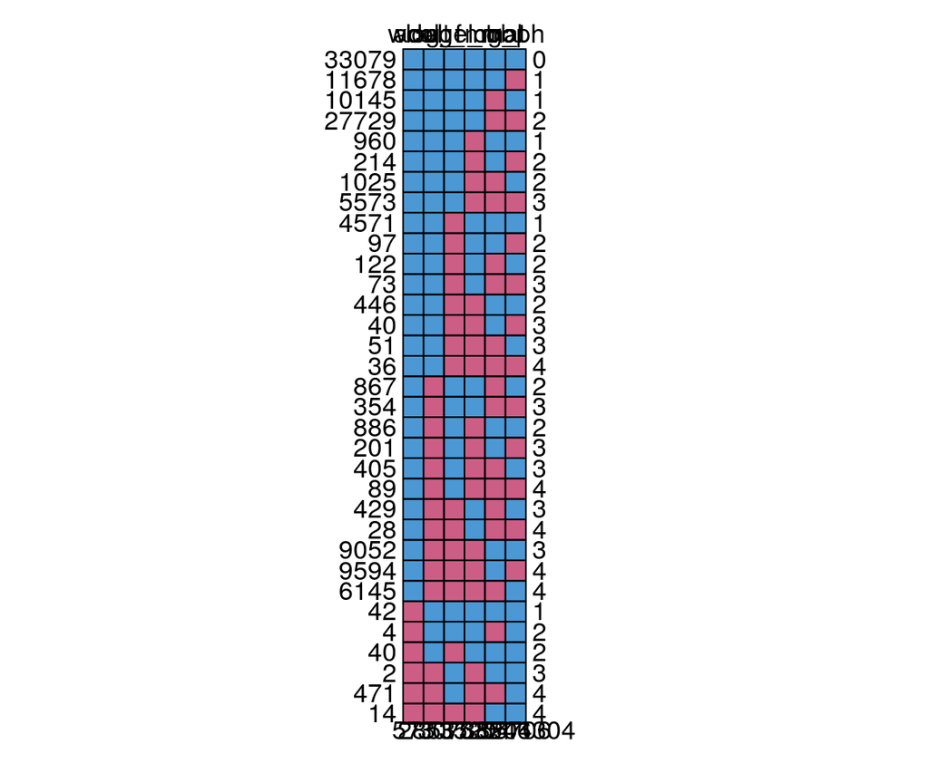

```
##       wcol log_f adult_mob age_mat log_l troph
## 33079    1     1         1       1     1     1      0
## 11678    1     1         1       1     1     0      1
## 10145    1     1         1       1     0     1      1
## 27729    1     1         1       1     0     0      2
## 960      1     1         1       0     1     1      1
## 214      1     1         1       0     1     0      2
## 1025     1     1         1       0     0     1      2
## 5573     1     1         1       0     0     0      3
## 4571     1     1         0       1     1     1      1
## 97       1     1         0       1     1     0      2
## 122      1     1         0       1     0     1      2
## 73       1     1         0       1     0     0      3
## 446      1     1         0       0     1     1      2
## 40       1     1         0       0     1     0      3
```

[output cut: 20 more lines]

```r
md.pattern(traits_premice_all %>% select(-species))
```

## 3.2 Examine patterns of missingness

Are the missing values missing completely at random, or at random, or not at random? Guessing that some variables are not missing at random due to data being available only for certain taxonomic groups, and perhaps we will need to perform MICE separately for certain classes or phyla since the relationships among variables may be quite different.

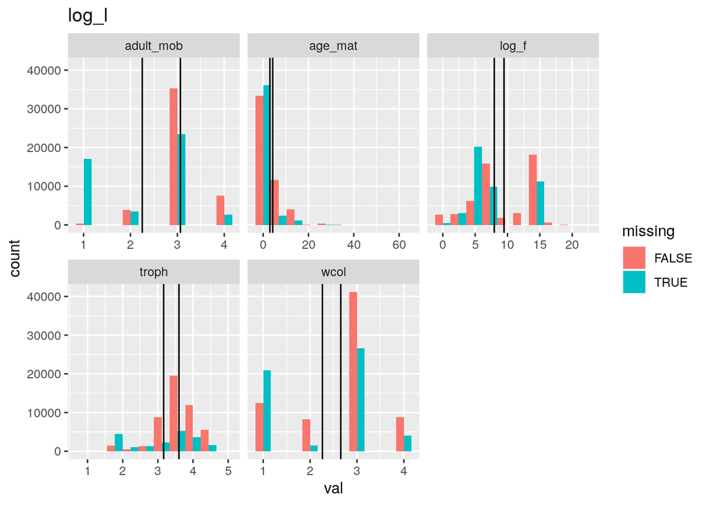

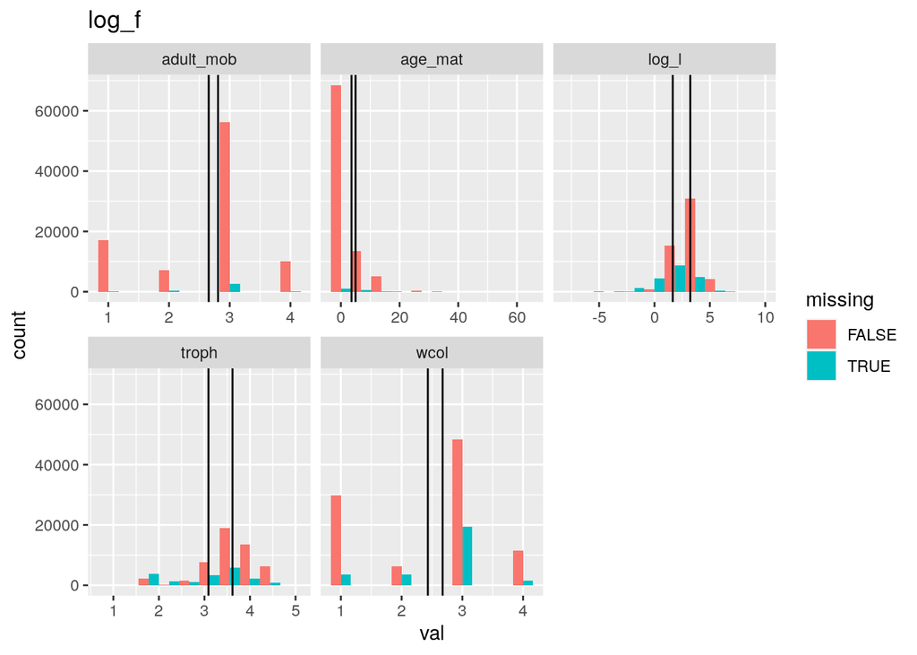

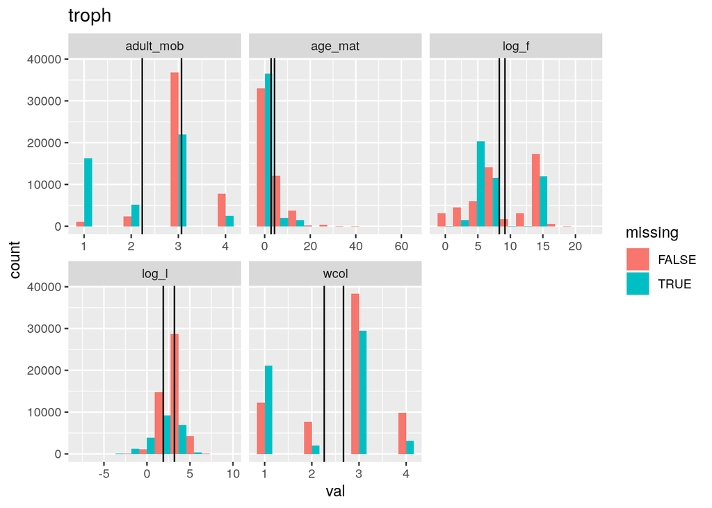

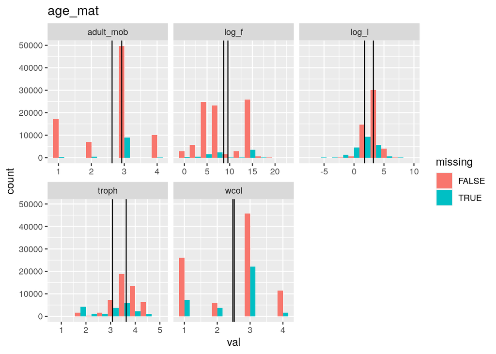

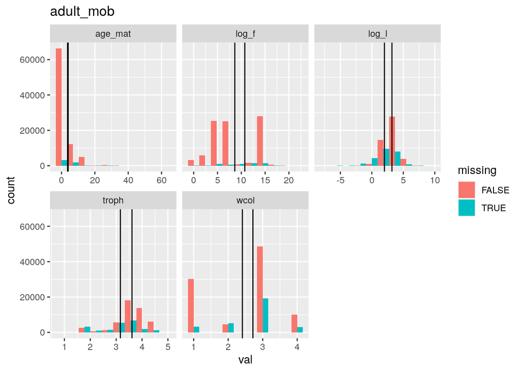

```r
mice_vars <- c('log_l', 'log_f', 'troph', 'age_mat', 'wcol', 'adult_mob')

### To pull into a long format, var types need to be compatible.  Using factor
### levels for water col position and adult mobility should still allow us
### to see problematic patterns...
test_df <- traits_premice_all %>%
  mutate(wcol = as.integer(wcol),
         adult_mob = as.integer(adult_mob))

for(v in mice_vars) { ### v <- mice_vars[1]
  ### v will iterate over the column with missing values

  ### if v == 'wcol' skip, since so few missing
  if(v == 'wcol') next()

  missing_df <- test_df %>%
    mutate(missing = is.na(.data[[v]]))

  missing_df_long <- missing_df %>%
    pivot_longer(mice_vars[mice_vars != v], names_to = 'var', values_to = 'val')

  missing_means <- missing_df_long %>%
    group_by(missing, var) %>%
    summarize(mu = mean(val, na.rm = TRUE))

  p <- ggplot() +
    geom_histogram(data = missing_df_long,
                   aes(x = val, fill = missing),
                   position = 'dodge', bins = 10) +
    geom_vline(data = missing_means, aes(xintercept = mu)) +
    facet_wrap( ~ var, scales = 'free_x') +
    labs(title = v)
  print(p)
}
```

Most don’t actually appear too bad!

It seems reasonable to break out certain taxonomic groups for MICE due to major differences in physiology. Explore a breakdown by verts (by class) and inverts (by phylum?). Examine inclusion of species found in AquaMaps (though use MICE on full set regardless of AquaMaps status).

```r
worms_spp <- assemble_worms()
am_spp <- get_am_spp_info()

worms_premice <- worms_spp %>%
  dt_join(traits_premice_all, by = 'species', type = 'inner')
n_distinct(worms_premice$species)
```

```
## [1] 56428
```

```r
worms_am_premice <- worms_premice %>%
  filter(species %in% am_spp$sciname)
n_distinct(worms_am_premice$species)
```

```
## [1] 24136
```